# TRF2 and R-loop overlap in HeLa

Quick proof of concept to see how much overlap there is between the publicly available HeLa TRF2 ChIP-seq and DRIP-seq datasets.

Here are their references:

- TRF-2 ChIP-seq
  - GEO: GSE46237
  - Reference: Marzec, et al, Cell (2015)
  - DOI: https://doi.org/10.1016/j.cell.2015.01.044
- DRIP-seq
  - GEO: GSE93368
  - Reference: Hamperl, et al, Cell (2017)
  - DOI: https://doi.org/10.1016/j.cell.2017.07.043

I’m still using the downloaded processed datasets. So here it goes: load, get ranges, overlap and plot.

```r
library(tidyverse)
library(GenomicRanges)
library(rtracklayer)

# TRF2 peaks
trf2_chip_seq <- read_tsv("../available_data_processed/GSM1126877_TRF2_HeLa_peaks_hg18.bed",
                            skip = 1,
                            col_names = c("chr", "start", "end"))
trf2_chip_seq <- with(trf2_chip_seq, GRanges(seqnames = chr,
                                             ranges = IRanges(start = start,
                                                              end = end),
                                             strand = "*",
                                             seqinfo = SeqinfoForUCSCGenome("hg18")))

ch <- import.chain("../available_data_processed/hg18ToHg19.over.chain")

seqlevelsStyle(trf2_chip_seq) <- "UCSC"

trf2_chip_seq <- unlist(liftOver(trf2_chip_seq, ch))

# Head-on - Head-on collisions
HO_HO_collisions <- read_tsv("../available_data_processed/GSE93368_DRIP_seq_HeLa_HO_HO_collisions.txt",
                             col_names = c("chr", "start", "end"))
HO_HO_collisions <- with(HO_HO_collisions, GRanges(seqnames = chr,
                                                   ranges = IRanges(start = start,
                                                                    end = end),
                                                   strand = "*"))

# Co-directional - co-directional collisions
CD_CD_collisions <- read_tsv("../available_data_processed/GSE93368_DRIP_seq_HeLa_CD_CD_collisions.txt",
                             col_names = c("chr", "start", "end"))
CD_CD_collisions <- with(CD_CD_collisions, GRanges(seqnames = chr,
                                                   ranges = IRanges(start = start,
                                                                    end = end),
                                                   strand = "*"))

# Head-on - co-directional collisions
HO_CD_collisions <- read_tsv("../available_data_processed/GSE93368_DRIP_seq_HeLa_HO_CD_collisions.txt",
                             col_names = c("chr", "start", "end", "id", "score", "strand"))
HO_CD_collisions <- with(HO_CD_collisions, GRanges(seqnames = chr,
                                                   ranges = IRanges(start = start,
                                                                    end = end),
                                                   strand = "*"))

collisions <- c(HO_HO_collisions, CD_CD_collisions, HO_CD_collisions)
```

Okay, sites are loaded. How do they compare in numbers and widths?

```r
# Count sites and covered width per chromosome
print(table(seqnames(trf2_chip_seq)))
```

```
##
##  chr1 chr10 chr11 chr15 chr16 chr18  chr2 chr21  chr3  chr4  chr5  chr7
##     5     2     2     1     4     1     4     1     1     2    14     1
##  chr8  chr9  chrX
##     4     3     1
```

```r
print(table(seqnames(collisions)))
```

```
##
##  chr1 chr10 chr11 chr12 chr13 chr14 chr15 chr16 chr17 chr18 chr19  chr2
##   464   186   209   210   122   148   163   110   157    68   106   395
## chr20 chr21 chr22  chr3  chr4  chr5  chr6  chr7  chr8  chr9  chrX
##    76    27    53   261   213   241   222   263   211   195   178
```

```r
print(summary(width(trf2_chip_seq)))
```

```
##    Min. 1st Qu.  Median    Mean 3rd Qu.    Max.
##    39.0    41.0   161.0   212.8   241.0  1521.0
```

```r
print(summary(width(collisions)))
```

```
##    Min. 1st Qu.  Median    Mean 3rd Qu.    Max.
##   24000   24000   24000   24000   24000   24000
```

The discrepancy in number of sites is huge! The TRF2 ChIP-seq dataset has very few sites (46 in total), compared to the DRIP-seq derived collisions (4278).

Do they overlap at all?

```r
countOverlaps(trf2_chip_seq, collisions)
```

```
##  [1] 0 0 0 0 0 0 0 0 0 0 0 0 0 0 0 0 0 0 0 0 0 0 0 0 0 0 0 0 0 0 0 0 1 0 0
## [36] 0 0 0 0 0 0 1 0 0 0 0
```

```r
sum(countOverlaps(trf2_chip_seq, collisions))
```

```
## [1] 2
```

Nope. Not very exciting. Just two overlaps between the TRF2 sites and the collision sites.

What about average DRIP-seq signal around TRF2 sites?

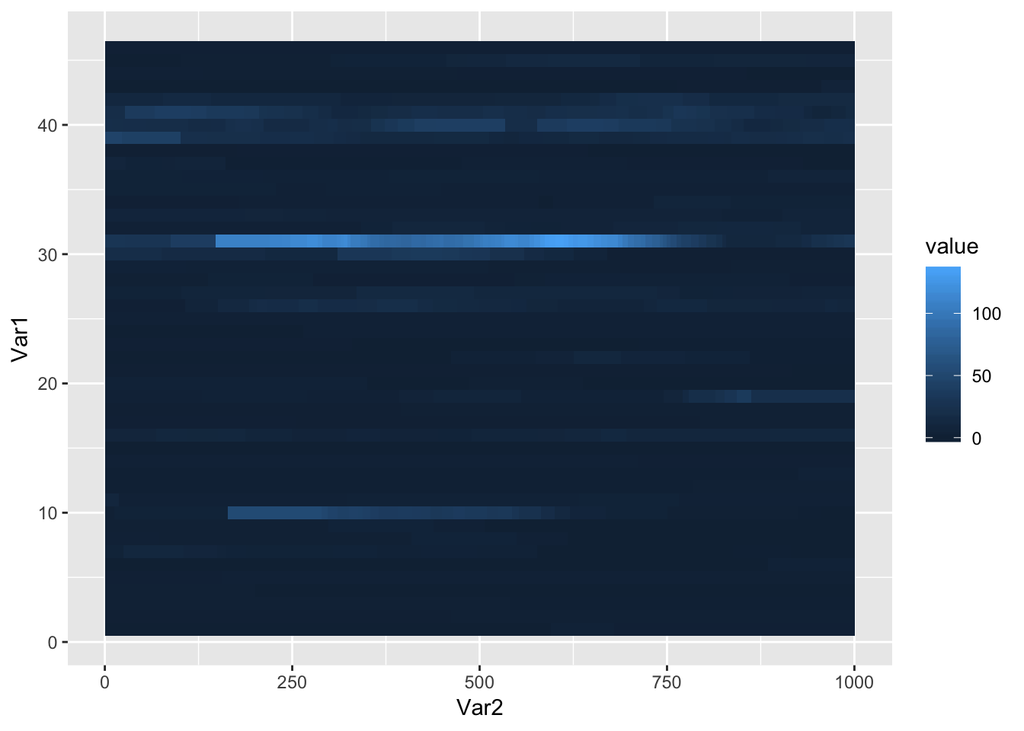

```r
trf2_windows <- resize(trf2_chip_seq, width = 1000,  fix = "center")
trf2_windows <- trim(trf2_windows)
trf2_windows <- trf2_windows[width(trf2_windows) == 1000]

drip_seq_signal_rep1 <- import("../available_data_processed/GSM2452072_ip_gl3.bw")
drip_seq_signal_rep1 <- coverage(drip_seq_signal_rep1, weight = drip_seq_signal_rep1$score)

trf2_drip_windows_signal_rep1 <- c()

for (chr in unique(seqnames(trf2_windows))) {

    trf2_drip_windows_signal_rep1 <- rbind(trf2_drip_windows_signal_rep1,
                               as.matrix(Views(drip_seq_signal_rep1[[chr]],
                                               ranges(trf2_windows[seqnames(trf2_windows) == chr]))))
}

drip_seq_signal_rep2 <- import("../available_data_processed/GSM2668157_ip_gl3_rep2.bw")
drip_seq_signal_rep2 <- coverage(drip_seq_signal_rep2, weight = drip_seq_signal_rep2$score)

trf2_drip_windows_signal_rep2 <- c()

for (chr in unique(seqnames(trf2_windows))) {

    trf2_drip_windows_signal_rep2 <- rbind(trf2_drip_windows_signal_rep2,
                               as.matrix(Views(drip_seq_signal_rep2[[chr]],
                                               ranges(trf2_windows[seqnames(trf2_windows) == chr]))))
}

drip_seq_input_rep1 <- import("../available_data_processed/GSM2452073_input_gl3.bw")
drip_seq_input_rep1 <- coverage(drip_seq_input_rep1, weight = drip_seq_input_rep1$score)

trf2_drip_windows_input_rep1 <- c()

for (chr in unique(seqnames(trf2_windows))) {

    trf2_drip_windows_input_rep1 <- rbind(trf2_drip_windows_input_rep1,
                               as.matrix(Views(drip_seq_input_rep1[[chr]],
                                               ranges(trf2_windows[seqnames(trf2_windows) == chr]))))
}


drip_seq_input_rep2 <- import("../available_data_processed/GSM2668158_input_gl3_rep2.bw")
drip_seq_input_rep2 <- coverage(drip_seq_input_rep2, weight = drip_seq_input_rep2$score)

trf2_drip_windows_input_rep2 <- c()

for (chr in unique(seqnames(trf2_windows))) {

    trf2_drip_windows_input_rep2 <- rbind(trf2_drip_windows_input_rep2,
                               as.matrix(Views(drip_seq_input_rep2[[chr]],
                                               ranges(trf2_windows[seqnames(trf2_windows) == chr]))))
}

trf2_drip_windows_signal_rep1 %>% reshape2::melt() %>%
  ggplot(aes(x = Var2, y = Var1, fill = value)) + geom_tile()
```

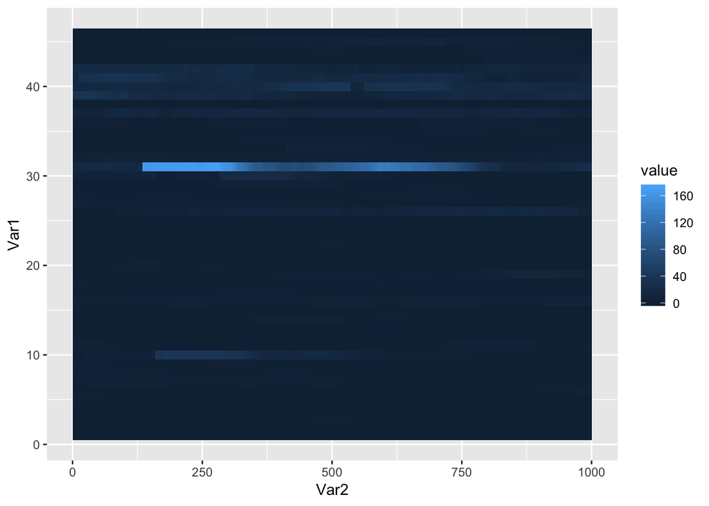

```r
trf2_drip_windows_signal_rep2 %>% reshape2::melt() %>%
  ggplot(aes(x = Var2, y = Var1, fill = value)) + geom_tile()
```

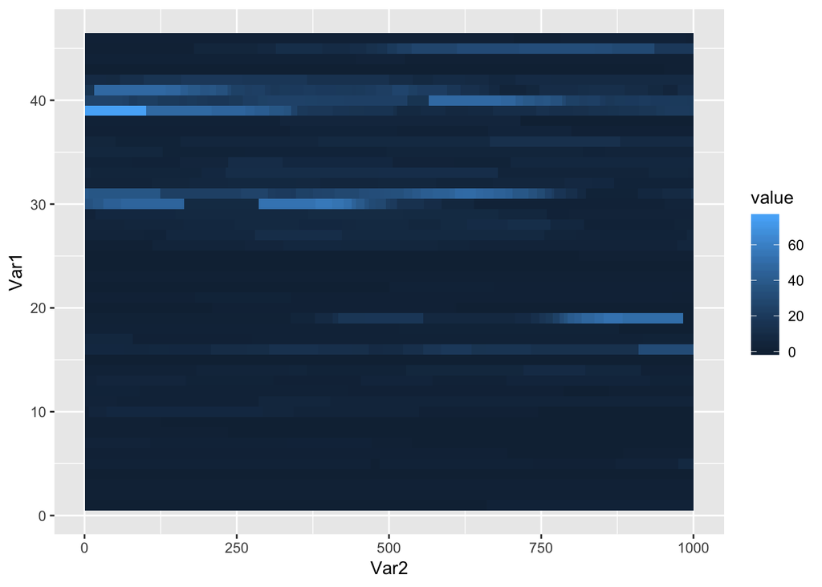

```r
trf2_drip_windows_input_rep1 %>% reshape2::melt() %>%
  ggplot(aes(x = Var2, y = Var1, fill = value)) + geom_tile()
```

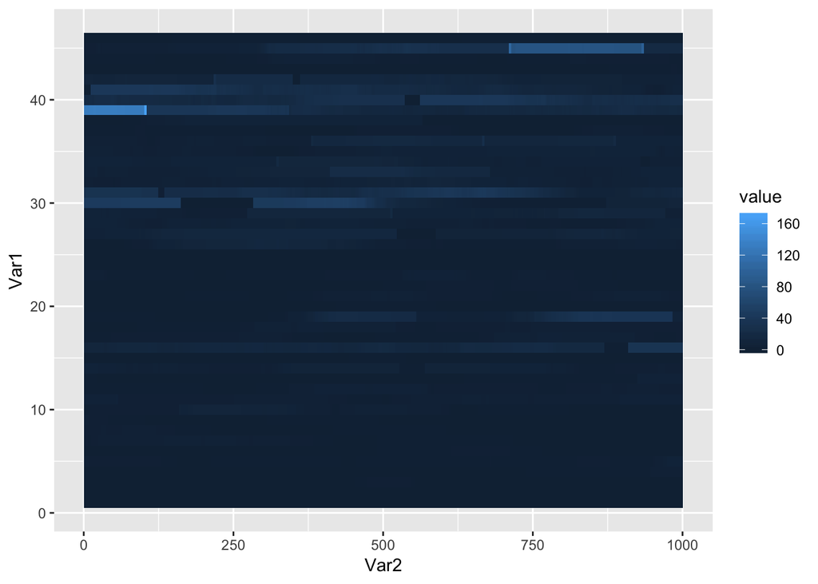

```r
trf2_drip_windows_input_rep2 %>% reshape2::melt() %>%
  ggplot(aes(x = Var2, y = Var1, fill = value)) + geom_tile()
```

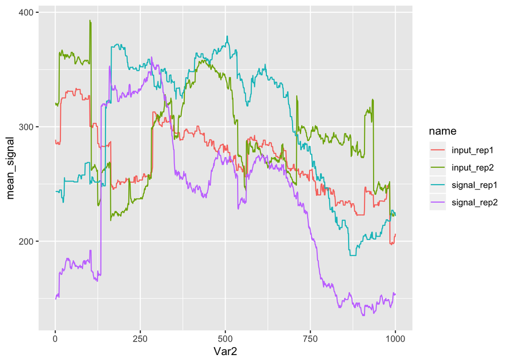

```r
rbind(trf2_drip_windows_signal_rep1 %>% reshape2::melt() %>% mutate(name = "signal_rep1"),
      trf2_drip_windows_signal_rep2 %>% reshape2::melt() %>% mutate(name = "signal_rep2"),
      trf2_drip_windows_input_rep1 %>% reshape2::melt() %>% mutate(name = "input_rep1"),
      trf2_drip_windows_input_rep2 %>% reshape2::melt() %>% mutate(name = "input_rep2")) %>%
  group_by(name, Var2) %>%
  dplyr::summarise(mean_signal = sum(value, na.rm= TRUE)) %>%
  ggplot(aes(x = Var2, y = mean_signal, colour = name)) + geom_line()
```

So TRF2 sites don’t really seem to have an increase in signal. I better stick with bibliography.